# R Notebook

```r
library(geosphere)
library(maptools)
library(raster)
library(dplyr)
library(rgdal)
library(rgeos)
library(geosphere)
library(nplr)
library(pscl)
library(ROCR)
library(likelihood)
library(hexbin)
library(RColorBrewer)
```

```r
w_dir <- "C:/Users/zacha/Desktop/Truncated_Scrapple/Inputs/"
out_dir <-  "C:/Users/zacha/Desktop/Truncated_Scrapple/Outputs/"
```

Wind data This is Grit metdata fro the University of Idaho http://www.climatologylab.org/gridmet.html From their website.

WHAT IS GRIDMET? gridMET is a dataset of daily high-spatial resolution (~4-km, 1/24th degree) surface meteorological data covering the contiguous US from 1979-yesterday. We have also extended these data to cover southern British Columbia in our real time products. These data can provide important inputs for ecological, agricultural, and hydrological models. These data are updated daily. gridMET is the preferred naming convention for these data; however, the data are also known as cited as METDATA.

http://www.climatologylab.org/gridmet.html

[meta](https://cida.usgs.gov/thredds/dodsC/UofIMETDATA.html)

The ecoregion map is used to locate the windspeed and the fwi data for each time step.

```r
fwi_dat <- read.csv(paste0(w_dir,"11_Eco_Climate.csv"),stringsAsFactors = FALSE)
wind_map<- raster::raster(paste(w_dir,"11_Ecoregions.tif",sep=""))
```

```
Discarded datum unknown in CRS definition: +proj=utm +zone=17 +ellps=GRS80 +towgs84=0,0,0,0,0,0,0 +units=m +no_defs,
 but +towgs84= values preservedDiscarded datum Unknown based on GRS80 ellipsoid in CRS definition,
 but +towgs84= values preserved
```

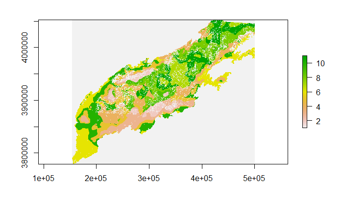

```r
wsv_dat <- read.csv(paste(w_dir,"Wind_1028.csv",sep=""),stringsAsFactors = FALSE)

colnames(wsv_dat) <- c("date", "eco1", 'eco2', 'eco3', 'eco4','eco5','eco6','eco8','eco9','eco10','eco11')
#wsv_dat<-wsv_dat[,c(-1)]
plot(wind_map)
```

```r
unique(wind_map$X11_Ecoregions)
```

```
 [1]  1  2  3  4  5  6  7  8  9 10 11
```

```r
ExampleRaster<-raster(paste(w_dir,"11_Ecoregions.tif",sep=""))
```

```
Discarded datum unknown in CRS definition: +proj=utm +zone=17 +ellps=GRS80 +towgs84=0,0,0,0,0,0,0 +units=m +no_defs,
 but +towgs84= values preservedDiscarded datum Unknown based on GRS80 ellipsoid in CRS definition,
 but +towgs84= values preserved
```

```r
projy<-crs(ExampleRaster)

### This is the landis-II fuel imput for timestep 10
fccs_raster<-raster(paste(w_dir,"Fuel_129.IMG",sep=""))
#plot(fccs_raster)
crs(fccs_raster)<-projy
extent(fccs_raster)<-extent(ExampleRaster)
plot(fccs_raster)
```

```r
r=fccs_raster
r[r==0] <- NA

fill.na <- function(x, i=5) {
  if( is.na(x)[i] ) {
    return( round(mean(x, na.rm=TRUE),0) )
  } else {
    return( round(x[i],0) )
  }
}

r2 <- focal(r, w = matrix(1,3,3), fun = fill.na,
            pad = TRUE, na.rm = FALSE )
plot(r2)
r3<-focal(r2, w = matrix(1,3,3), fun = fill.na,
            pad = TRUE, na.rm = FALSE )

plot(r3)

r4<-focal(r3, w = matrix(1,3,3), fun = fill.na,
            pad = TRUE, na.rm = FALSE )

plot(r4)
fuel_map<-r4

plot(fuel_map)
writeRaster(fuel_map,paste0(w_dir,"Interpolated_FuelMap.tif"))
```

```r
fuel_map<-raster(paste0(w_dir,"Interpolated_FuelMap.tif"))
```

```
Discarded datum Unknown_based_on_GRS80_ellipsoid in CRS definition: +proj=utm +zone=17 +ellps=GRS80 +towgs84=0,0,0,0,0,0,0 +units=m +no_defs,
 but +towgs84= values preservedDiscarded datum Unknown based on GRS80 ellipsoid in CRS definition,
 but +towgs84= values preserved
```

```r
uphill_azi_map<- raster(paste(w_dir,"SAPPS_aspect_inverted_atModelRes.tif",sep=""))
```

```
Discarded datum unknown in CRS definition: +proj=utm +zone=17 +ellps=GRS80 +towgs84=0,0,0,0,0,0,0 +units=m +no_defs,
 but +towgs84= values preservedDiscarded datum Unknown based on GRS80 ellipsoid in CRS definition,
 but +towgs84= values preserved
```

```r
#uphill_azi_map <- projectRaster(slope_azi_map, to = fuel_map, method='bilinear')
slope_map <-  raster(paste(w_dir,"SAPPS_Slope_ChrisArcmapprocess_modelres.tif",sep=""))
```

```
Discarded datum unknown in CRS definition: +proj=utm +zone=17 +ellps=GRS80 +towgs84=0,0,0,0,0,0,0 +units=m +no_defs,
 but +towgs84= values preservedDiscarded datum Unknown based on GRS80 ellipsoid in CRS definition,
 but +towgs84= values preserved
```

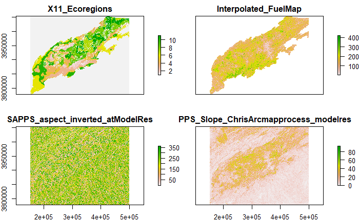

```r
#wind_map <- projectRaster(wind_map, to = fuel_map, method='ngb')
##Stacking all rasters as a test
climate_stack <- stack(wind_map, fuel_map, uphill_azi_map, slope_map)
plot(climate_stack)
```

```r
#Empty objects and column names and stuff used in loops
newfire<-readOGR(paste(w_dir,"fire_geomac_loc.shp",sep=""))
newfire1<-newfire[newfire$incidentna!=0,]
newfire2<-newfire[newfire$incidentna==0,]
newfire$per
```

```r
newfire_df<-data.frame(newfire)
perimeter_map<-newfire

perimeter_map$TrueDate<-as.Date(perimeter_map$perimeterd)
perimeter_map$TrueDate[is.na(perimeter_map$TrueDate)]<-as.Date(perimeter_map$date_[is.na(perimeter_map$TrueDate)])
perimeter_map<-perimeter_map[perimeter_map$TrueDate<"2017-01-01",]
perimeter_map$incidentna[perimeter_map$incidentna=='0']<-perimeter_map$fire_name[perimeter_map$incidentna=='0']
perimeter_map$incidentna[perimeter_map$incidentna==0]<-perimeter_map$fire_name[perimeter_map$incidentna==0]
DFP<-as.data.frame(perimeter_map)

#date_ and perimeterd
max(perimeter_map$TrueDate)
```

```
[1] "2016-12-13"
```

```r
#firenames<-as.data.frame(unique(newfire$))
perimeter_map
```

```
class       : SpatialPolygonsDataFrame
features    : 573
extent      : 160272.6, 488661.2, 3814642, 4072882  (xmin, xmax, ymin, ymax)
crs         : +proj=utm +zone=17 +datum=NAD83 +units=m +no_defs
variables   : 65
names       :    acres, agency, time_,                 comments, date_uploa, year_, active, unit_id,  fire_name, fire_num,      date_, st_area_sh, st_length_,      fire,  load_date, ...
min values  :        0,    BIA,     0,                      FGX, 2007/06/05,     0,      N,       0,          0,        0, 2007/05/30,          0,          0,         0, 2008/05/08, ...
max values  : 7749.151,   USFS,  2200, WFDSS; IR heat perimeter, 2007/06/27,  2015,      Y,  VA-VAF, Wolf Creek,     JY8B, 2015/08/16,    0.00313,    0.36996, Waucheesi, 2015/08/16, ...
```

```r
fire_names<-as.character(perimeter_map$incidentna)
#print(allnames)

unique(newfire$incidentna)
```

```
 [1] "0"                            "BOARDTREE"                    "BOTELER"
 [4] "BUCK CREEK"                   "Sciota Road"                  "Halls Top"
 [7] "WASHINGTON'S CREEK"           "BULLPEN"                      "State Line"
[10] "Raccoon Mountain"             "Railroad Grade 2016"          "PENTECOSTAL CHURCH"
[13] "SILVER MINE"                  "SALLY SMITH"                  "CATHY GAP"
[16] "CHARLEY CREEK"                "Chestnut Knob"                "WHITEWATER"
[19] "COBBLY NOB"                   "Pinnacle Mountain"            "Rock Mountain"
[22] "OLD ROUGHY"                   "PARTY ROCK"                   "Upper creek"
[25] "TIGER CREEK"                  "CLIFFSIDE"                    "DICK'S CREEK"
[28] "GRAPE COVE"                   "MULBERRY"                     "HWY 151"
[31] "Rough Ridge"                  "CHIMNEY 2"                    "Irwin Mill"
[34] "Big Poplar"                   "Pinball"                      "CHIMNEY TOPS 2"
[37] "BURRELL 42"                   "MAPLE SPRINGS"                "Rattlesnake Hollow"
[40] "CLEAR CREEK"                  "East Miller Cove"             "Quarry Creek"
[43] "JONES GAP"                    "CHIMNEY TOP"                  "DOBSON 3"
[46] "WINE SPRINGS"                 "Wolf Creek"                   "AVEY BRANCH"
[49] "TELLICO"                      "KNOB"                         "BURRELL"
[52] "MOSES CREEK"                  "HOWARD GAP"                   "JONES CREEK"
[55] "FEREBEE MEMORIAL"             "TIMBER RIDGE"                 "MAY BRANCH"
[58] "MUSKRAT"                      "HORTON"                       "MOSS KNOB"
[61] "Neddy Mountain Road"          "CAMP BRANCH"                  "CONSEEN DRIVE"
[64] "GLADYS BRANCH FORNEY AREA WF" "RIDGE GAP"                    "HAPPY VALLEY RIDGE"
[67] "ROCKHOUSE"                    "DOBSON 4"                     "ROUGH RIDGE"
[70] "Bakers Grave"                 "2 Mile"                       "NICK"
[73] "Georges Branch"               "DEER PARK"                    "SUGAR COVE"
[76] "WHITE CREEK"                  "DOBSON KNOB"                  "CROW MOUNTAIN"
```

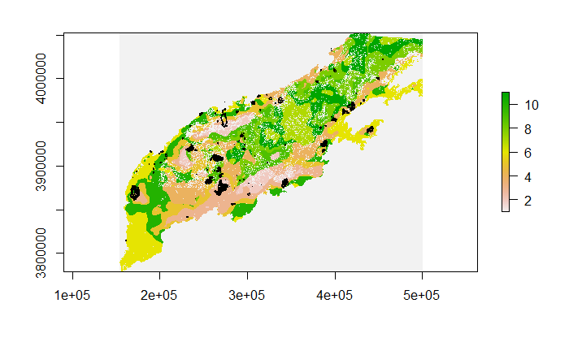

```r
###Climate regions
plot(ExampleRaster)
plot(newfire,add=TRUE)
```

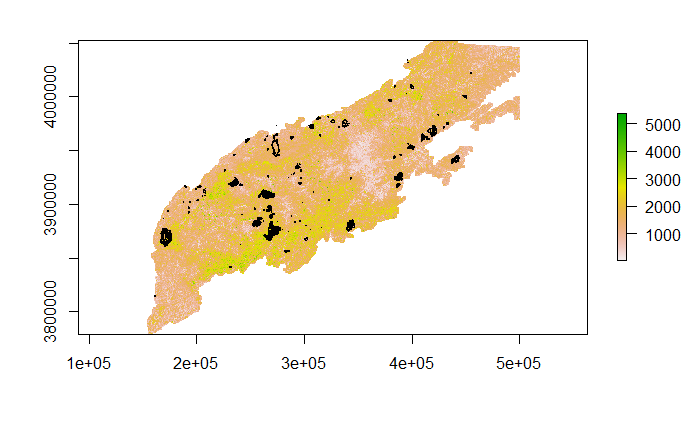

```r
plot(fuel_map)
plot(newfire,add=TRUE)
```

```r
fwi_dat_slim <- fwi_dat[,c(1,2,3,22)]
colnames(fwi_dat)
```

```
 [1] "Year"                 "Timestep"             "EcoregionName"        "EcoregionIndex"
 [5] "ppt"                  "min_airtemp"          "max_airtemp"          "std_ppt"
 [9] "std_temp"             "winddirection"        "windspeed"            "ndeposition"
[13] "co2"                  "relativehumidity"     "min_relativehumidity" "max_relativehumidity"
[17] "specifichumidty"      "par"                  "ozone"                "shortwave"
[21] "temperature"          "FWI"                  "X"
```

```r
fwi_date_info <- with(fwi_dat_slim, paste(Year, Timestep))
fwi_dates <- strptime(fwi_date_info, "%Y %j") #COnverting from julian day to y-m-d
#unique(fwi_date_dat$EcoregionName)
fwi_date_dat <- cbind(as.POSIXct(fwi_dates), fwi_dat_slim[,3:4]) #attaching
colnames(fwi_date_dat) <- c("Date", "Ecoregion", "FWI")
fwi_date_dat$Ecoregion<-gsub("eco","",fwi_date_dat$Ecoregion)
fwi_date_dat$Ecoregion<-as.numeric(as.character(fwi_date_dat$Ecoregion))
```

### Visually filtering fires.

Looking for fires, that are not just the final burn shape.

```r
#Setting up names of fire perimeter shapefiles
years <- 1992:2017
```

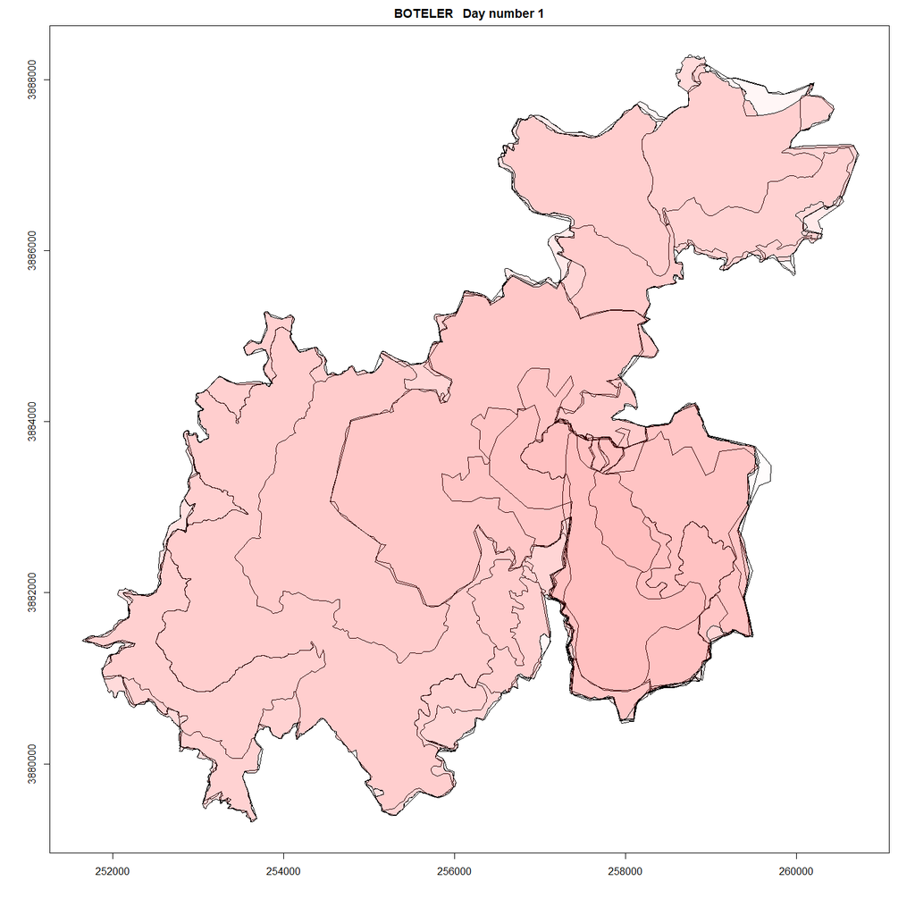

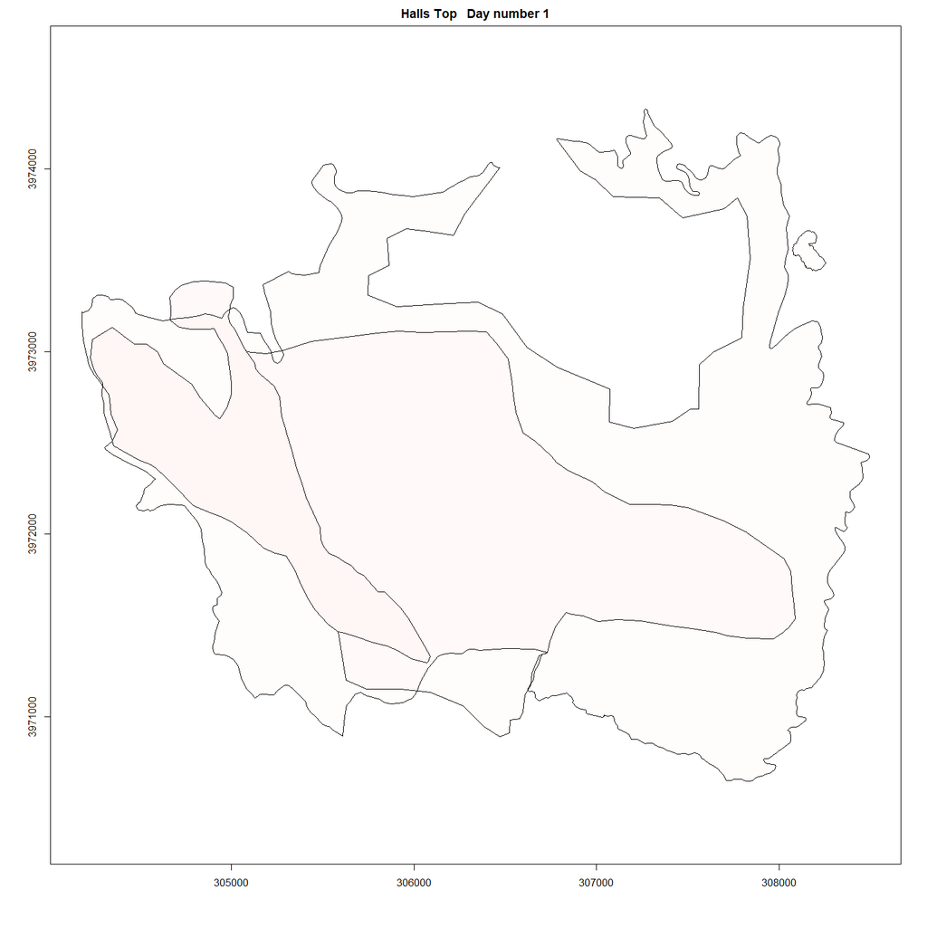

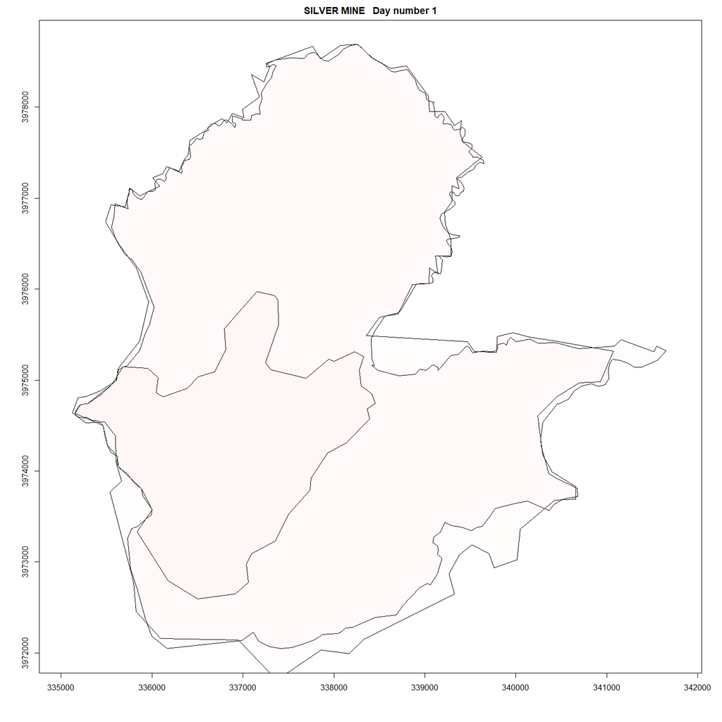

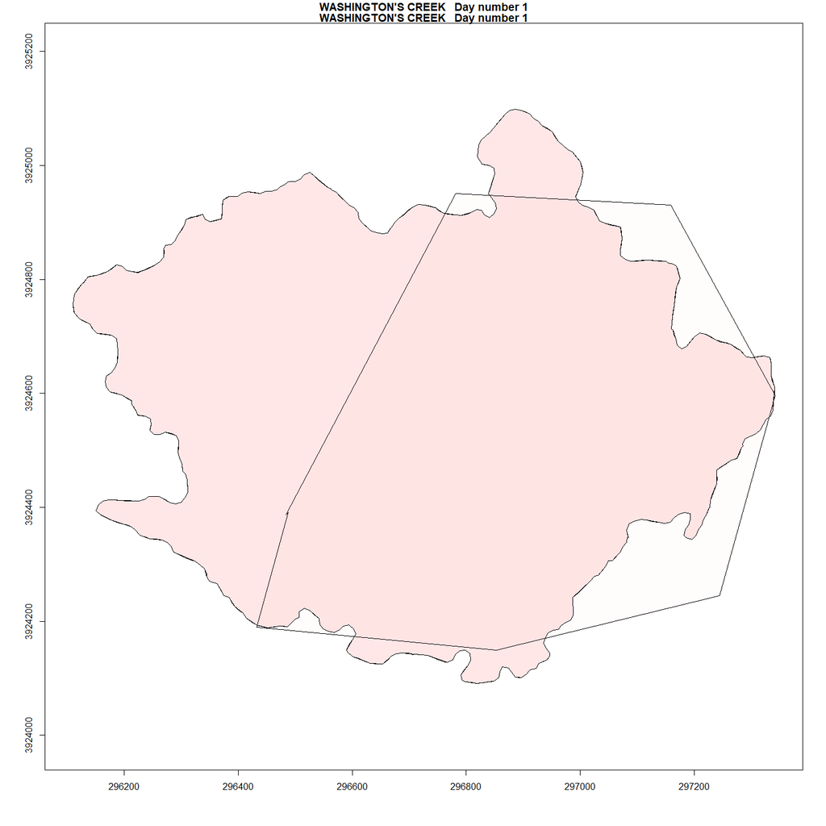

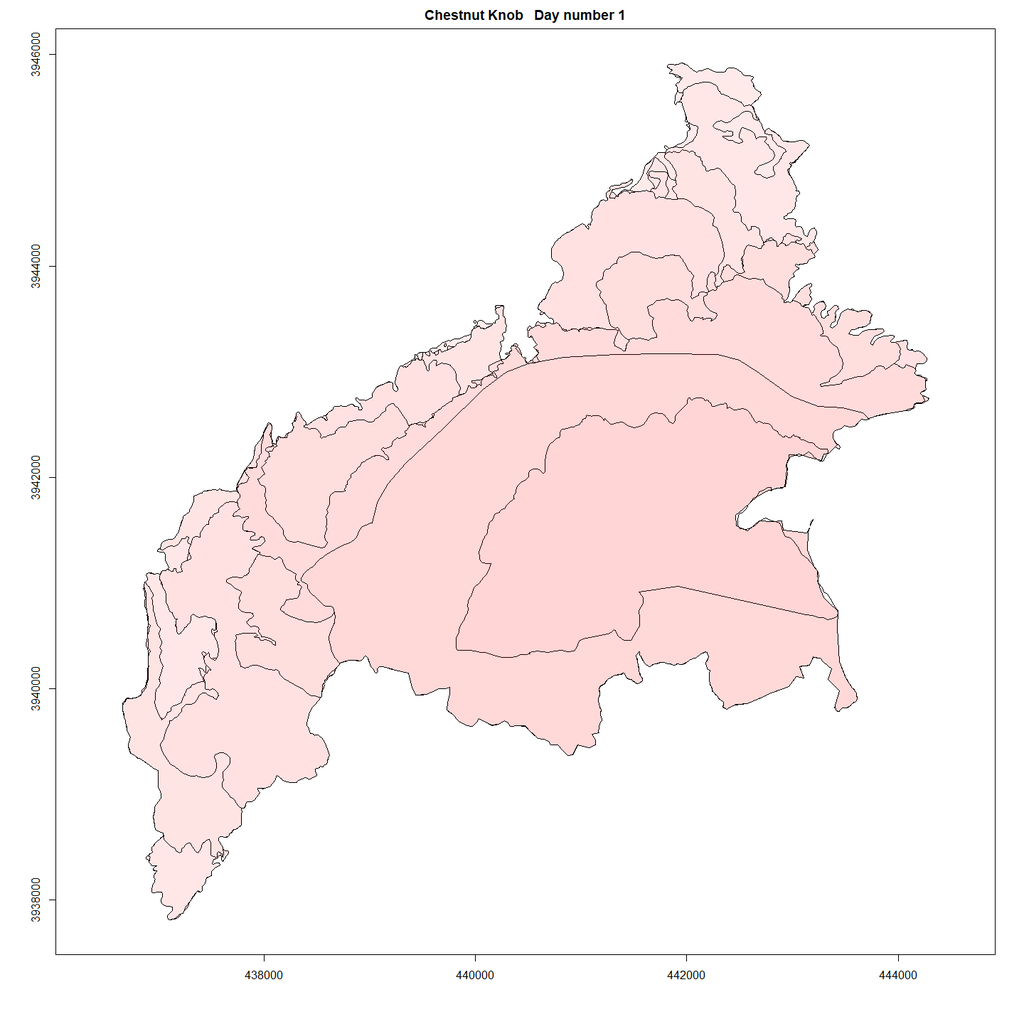

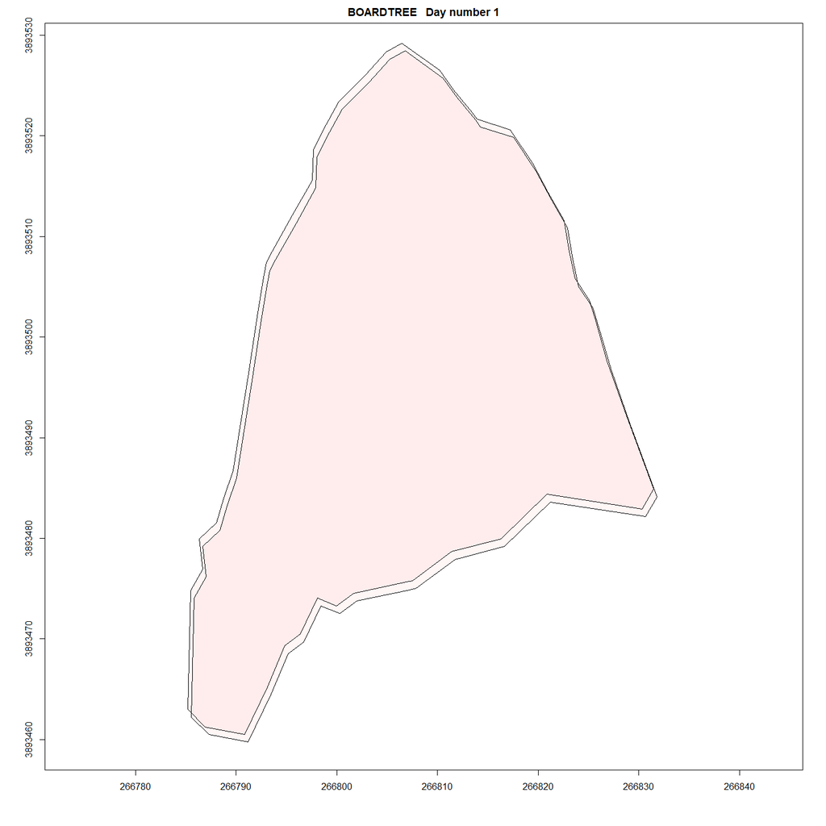

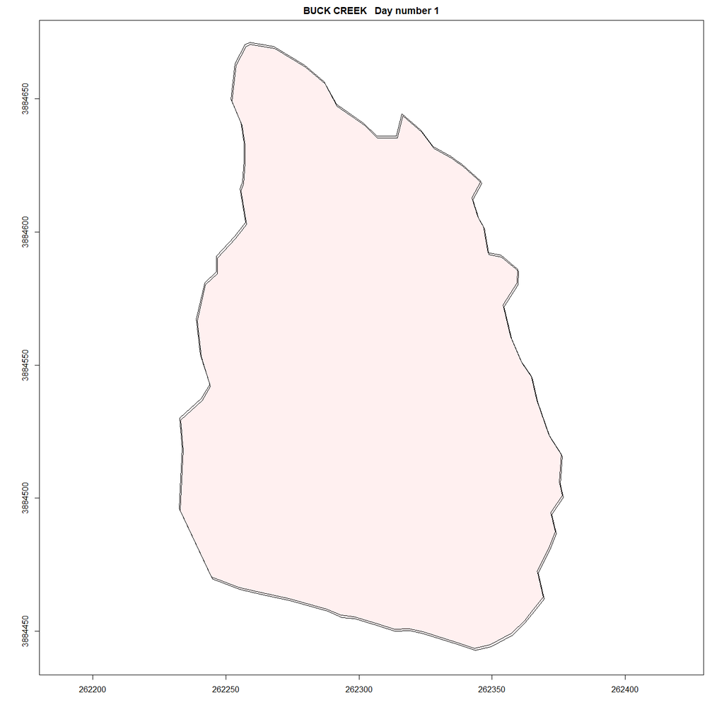

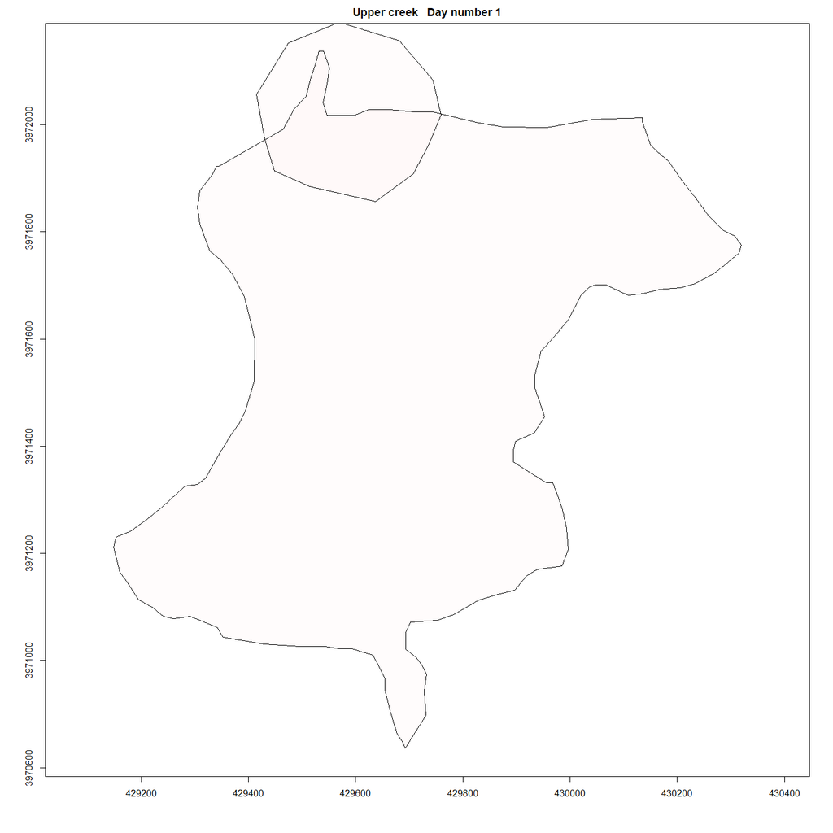

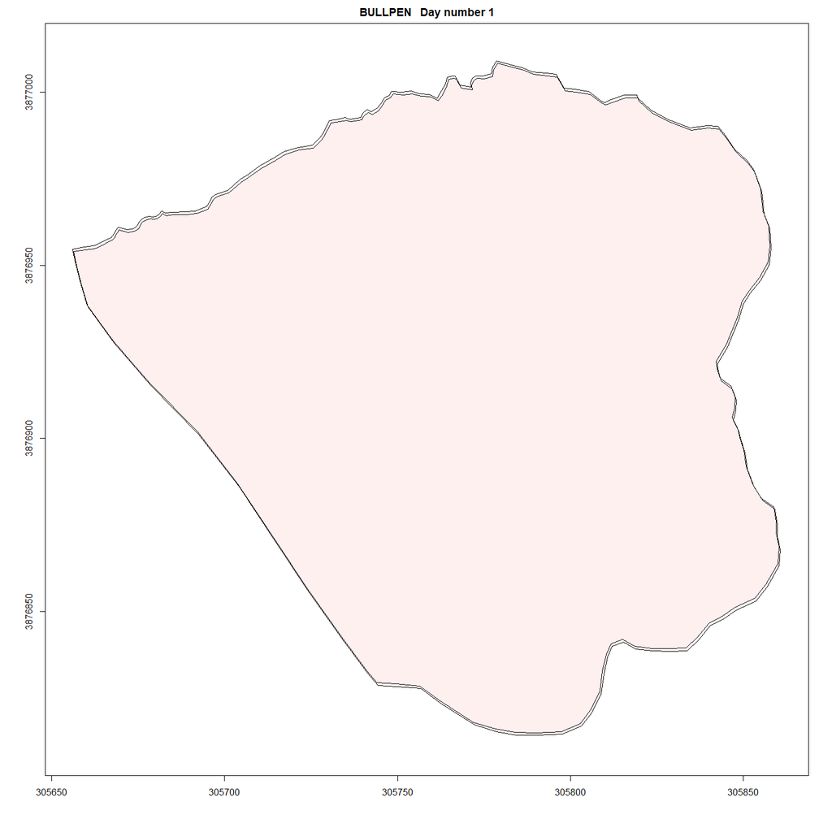

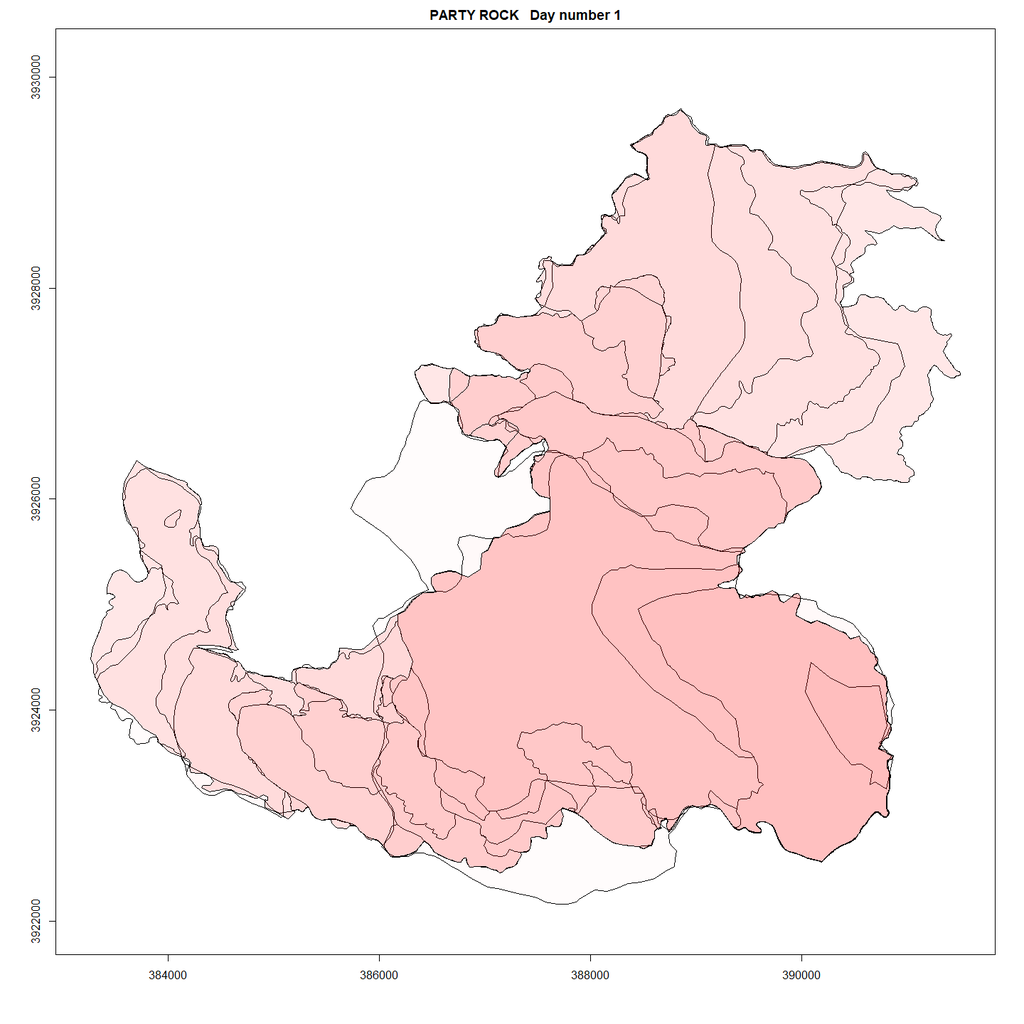

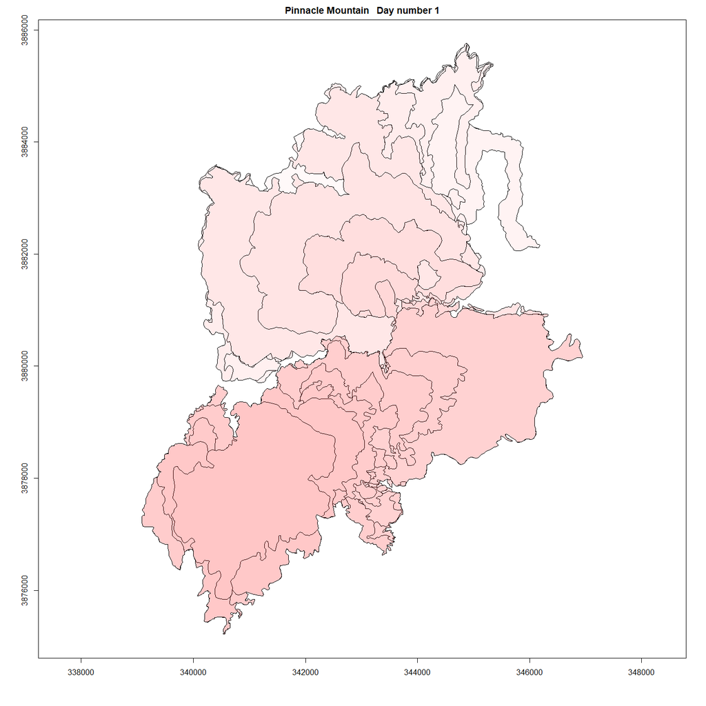

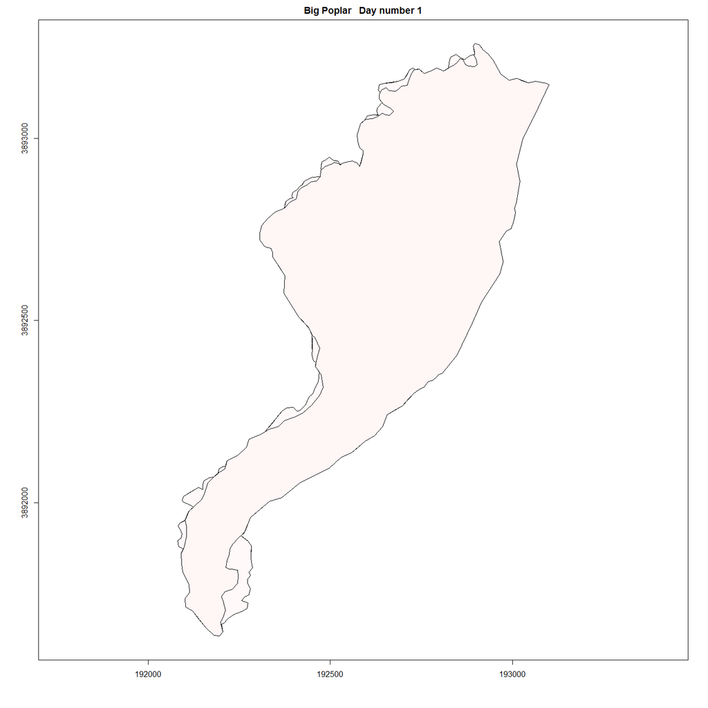

[4 more figures not shown]

```r
  library(raster)
  climate_day_mat <- NULL
 # One_fire <- newfire[newfire$incidentna,] #This pulls out all fire names

  ##Select for fires that lasted more than 1 day
  fire_names_manydays <- unique(fire_names[duplicated(fire_names)])
  fire_names_manydays <- fire_names_manydays[!is.na(fire_names_manydays)] ##Remo
  for (i in 1:length(fire_names_manydays)){

    #fire_select <- perimeter_map[perimeter_map$fire_name == fire_names_manydays[i],] #selecting an individual fire_ doesn't work 7/7 #
    #print(fire_names_manydays[i])
    fire_select <- subset(perimeter_map, perimeter_map$incidentna ==fire_names_manydays[i])#selecting an individual fire
    fire_days <- as.character(sort(unique(fire_select$perimeterd)))

   #print(max)
   #print(max[4])
   #if(is.na(fire_days)){fire_days<-as.character(sort(unique(fire_select$date_)))}
    #sorting fire days into chronological order
   # print(fire_days)
    ##Add a short escape in case fire days <= 1
    if(length(fire_days) < 2) next
    #par(mfrow=c(3,3))
    for(j in 1:(length(fire_days))){
    max<-raster::bbox( subset(fire_select, fire_select$perimeterd == max(fire_days)))
    fire_day_select <- subset(fire_select, fire_select$perimeterd == fire_days[j])
    if(j==1){
       plot(fire_day_select,axes=T,main=paste0(fire_day_select$incidentna,"   Day number ",j),xlim=c(max[1],max[3]),ylim=c(max[2],max[4]),col=adjustcolor('red',alpha.f = .01))
    }else(
    plot(fire_day_select,axes=T,add=T,main=paste0(fire_day_select$incidentna,"   Day number ",j),xlim=c(max[1],max[3]),ylim=c(max[2],max[4]),col=adjustcolor('red',alpha.f = .01)))
    #selecting the first fire perim from that date, in case there are multiples
    }
  }
```

### Keep running list of cells to subtract out.

```r
unique(perimeter_map$incidentna)
```

```
 [1] "Stoney Ridge"                 "Laurel Falls 2"               "BOARDTREE"
 [4] "BOTELER"                      "BUCK CREEK"                   "Sciota Road"
 [7] "Halls Top"                    "WASHINGTON'S CREEK"           "BULLPEN"
[10] "State Line"                   "Raccoon Mountain"             "Railroad Grade 2016"
[13] "PENTECOSTAL CHURCH"           "SILVER MINE"                  "SALLY SMITH"
[16] "CATHY GAP"                    "CHARLEY CREEK"                "Chestnut Knob"
[19] "WHITEWATER"                   "COBBLY NOB"                   "Pinnacle Mountain"
[22] "Rock Mountain"                "OLD ROUGHY"                   "PARTY ROCK"
[25] "Upper creek"                  "TIGER CREEK"                  "CLIFFSIDE"
[28] "DICK'S CREEK"                 "GRAPE COVE"                   "MULBERRY"
[31] "HWY 151"                      "Rough Ridge"                  "CHIMNEY 2"
[34] "Irwin Mill"                   "Big Poplar"                   "Pinball"
[37] "CHIMNEY TOPS 2"               "BURRELL 42"                   "MAPLE SPRINGS"
[40] "Rattlesnake Hollow"           "CLEAR CREEK"                  "East Miller Cove"
[43] "Quarry Creek"                 "JONES GAP"                    "CHIMNEY TOP"
[46] "DOBSON 3"                     "WINE SPRINGS"                 "Wolf Creek"
[49] "AVEY BRANCH"                  "TELLICO"                      "KNOB"
[52] "BURRELL"                      "MOSES CREEK"                  "HOWARD GAP"
[55] "JONES CREEK"                  "FEREBEE MEMORIAL"             "TIMBER RIDGE"
[58] "MAY BRANCH"                   "MUSKRAT"                      "HORTON"
[61] "MOSS KNOB"                    "Neddy Mountain Road"          "CAMP BRANCH"
[64] "CONSEEN DRIVE"                "GLADYS BRANCH FORNEY AREA WF" "RIDGE GAP"
[67] "HAPPY VALLEY RIDGE"           "ROCKHOUSE"                    "DOBSON 4"
[70] "ROUGH RIDGE"                  "Bakers Grave"                 "2 Mile"
[73] "NICK"                         "Weed Lane"                    "Poplar"
[76] "Blue Gravel"                  "Bald Knob"                    "Shack"
[79] "Judes Gap"                    "Milligan"                     "Rag Mountain"
[82] "Table Rock"                   "Landfill"                     "Brown Mountain"
[85] "Oakey Top"                    "Joe Brown"                    "Gravel Stand Complex"
[88] "Sunrise"                      "Linville Complex"             "Big Starr Complex"
```

```r
print(fire_names_manydays)
```

```
 [1] "Stoney Ridge"        "Laurel Falls 2"      "BOTELER"
 [4] "Halls Top"           "SILVER MINE"         "WASHINGTON'S CREEK"
 [7] "Chestnut Knob"       "BOARDTREE"           "BUCK CREEK"
[10] "Upper creek"         "BULLPEN"             "PARTY ROCK"
[13] "Pinnacle Mountain"   "Big Poplar"          "Pinball"
[16] "Rough Ridge"         "CHIMNEY TOPS 2"      "DICK'S CREEK"
[19] "CLIFFSIDE"           "GRAPE COVE"          "Rattlesnake Hollow"
[22] "MAPLE SPRINGS"       "CHIMNEY TOP"         "Rock Mountain"
[25] "OLD ROUGHY"          "BURRELL"             "BURRELL 42"
[28] "WINE SPRINGS"        "KNOB"                "AVEY BRANCH"
[31] "Quarry Creek"        "CHARLEY CREEK"       "DOBSON 3"
[34] "MOSES CREEK"         "MAY BRANCH"          "MULBERRY"
[37] "Neddy Mountain Road" "CATHY GAP"           "HOWARD GAP"
[40] "JONES CREEK"         "JONES GAP"           "Irwin Mill"
[43] "CLEAR CREEK"         "TELLICO"             "COBBLY NOB"
[46] "WHITEWATER"          "TIMBER RIDGE"        "East Miller Cove"
[49] "Wolf Creek"          "FEREBEE MEMORIAL"    "HORTON"
[52] "HAPPY VALLEY RIDGE"  "Sciota Road"         "ROUGH RIDGE"
[55] "RIDGE GAP"           "MOSS KNOB"           "MUSKRAT"
[58] "CAMP BRANCH"         "HWY 151"             "NICK"
[61] "Weed Lane"           "Blue Gravel"         "Poplar"
[64] "Bald Knob"           "Judes Gap"           "Table Rock"
[67] "Oakey Top"           "Brown Mountain"      "Sunrise"
[70] "Linville Complex"    "Big Starr Complex"
```

```r
climate_day_mat <- NULL
```

[output not shown]

```r
#climate_day_mat2 <- NULL
# One_fire <- newfire[newfire$incidentna,] #This pulls out all fire names
wsv_dat_df<-as.data.frame(wsv_dat)
##Select for fires that lasted more than 1 day
fire_names_manydays <-fire_names[!duplicated(fire_names)]
fire_names_manydays <- fire_names_manydays[!is.na(fire_names_manydays)] ##Removing potential NAs
fire_names_manydays<- fire_names_manydays[fire_names_manydays %in% SoundInc]
#perimeter_map$ %in%(seq(2009,2016,1))


# print(fire_names_manydays)
for (i in 1:length(fire_names_manydays)){
  print(fire_names_manydays[i])

  fire_select <- subset(perimeter_map, perimeter_map$incidentna ==fire_names_manydays[i])#selecting an individual fire
  fire_days <- as.character(sort(unique(fire_select$TrueDate)))

  if(length(fire_days) < 2) next
  storedcells<-NULL
  dftest<-as.data.frame(fire_select)
  for(j in 1:(length(fire_days)-1)){

    fire_day_select <- subset(fire_select, fire_select$TrueDate == fire_days[j])# selecting the first day of the fire
    fire_day_select<-fire_day_select[order(fire_day_select$acres),]
    fire_day_select <- fire_day_select[1,] #selecting the first fire perim from that date, in case there are multiples
    #fire_day_centroid <- rgeos::gCentroid(fire_day_select) #Finding centroid for estimatign wind direction
    fire_day_select_1 <- subset(fire_select, fire_select$TrueDate== fire_days[j+1])#getting day 2 fire perimeter
    fire_day_select_1<-fire_day_select_1[order(fire_day_select_1$acres),]
    fire_day_select_1 <- fire_day_select_1[1,] #selecting the first fire perim from that date, in case there are multiples
    area_expansion <-(area(fire_day_select_1)/4046.86)-(area(fire_day_select)/4046.86)
    if(area_expansion < 30.00){
      next()
      }
    lastday<-j

  }
  for(j in 1:(length(fire_days)-1)){
    print(lastday)
    Failedvalues<-NA
    Successcells<-NA
    EndFailedvalues<-NA
    print(paste0("day  ",j))
    #Trying to capture Day 1 spread.
    #
    fire_day_select <- subset(fire_select, fire_select$TrueDate == fire_days[j])# selecting the first day of the fire
    fire_day_select<-fire_day_select[order(fire_day_select$acres),]
    fire_day_select <- fire_day_select[1,] #selecting the first fire perim from that date, in case there are multiples
    #fire_day_centroid <- rgeos::gCentroid(fire_day_select) #Finding centroid for estimatign wind direction
    fire_day_select_1 <- subset(fire_select, fire_select$TrueDate== fire_days[j+1])#getting day 2 fire perimeter
    fire_day_select_1<-fire_day_select_1[order(fire_day_select_1$acres),]
    fire_day_select_1 <- fire_day_select_1[1,] #selecting the first fire perim from that date, in case there are multiples
    area_expansion <-(area(fire_day_select_1)/4046.86)-(area(fire_day_select)/4046.86)





    if(area_expansion < 30.00){
      print("next")
      next()
      }

   # head(wsv_dat_df)
    wind_today<-wsv_dat_df %>%
      subset(date==gsub("/","-",paste0(fire_days[j],'T00:00:00Z')))
    WindMap<-climate_stack$X11_Ecoregions
    WindTrans=as.matrix(data.frame(was=c(1,2,3,4,5,6,8,9,10,11),
               is=as.numeric(t(wind_today[2:11]))))
    Wind_Reclas<-reclassify(WindMap,WindTrans)

    fire_today<-fwi_date_dat%>%
      subset(Date ==gsub("/","-",paste0(fire_days[j],'T00:00:00Z')))%>%
      arrange(Ecoregion)
    FireMap<-climate_stack$X11_Ecoregions
    FireTrans=as.matrix(data.frame(was=c(1,2,3,4,5,6,8,9,10,11),
               is=fire_today$FWI))
    FireWeather<-reclassify(FireMap,FireTrans)

   # plot(FireWeather)
    #Ecos<-climate_stack$X11_Ecoregions
    End_stack<-stack(climate_stack,FireWeather)
    End_stack<-stack(End_stack,Wind_Reclas)

    #Creating vector of fire dates. It doesnt work when I bind them below for some reason
    date_char <- as.POSIXct(as.character(fire_day_select$TrueDate)) #, format = "%Y-%m-%d", tz="" this stopped working? need to strip PDT then

    ##Extracting climate and fuels variables from raster stack.
    #This will compile a data frame of every cell that fire perimeters touch and whether
    day1 <- extract(End_stack, fire_day_select, cellnumbers = TRUE, df=TRUE, method="simple")

    day2 <- extract(End_stack, fire_day_select_1, cellnumbers = TRUE, df=TRUE, method="simple")


    # First find day not in stored, then find adajecnts, remove adjecnets in stored.

    day1cells<-day1$cell[!day1$cell %in% storedcells]
    storedcells<-c(storedcells,day1$cell)
    if( length(day1cells) >0){
    adjacentcells1<-adjacent(End_stack,day1cells,directions=4, pairs=TRUE,id=TRUE)
    adjacentcells1<-unique(adjacentcells1[,3])
    adjacentcells1<-adjacentcells1[!adjacentcells1 %in% storedcells]
    }else(adjacentcells1=NA)
    newspread<-day2$cell[!day2$cell %in% storedcells]
    Failedvalues<-data.frame()

    if( length(day1cells) >0){
    FailedCells=adjacentcells1[!adjacentcells1 %in% newspread]
    Failedvalues<-as.data.frame(extract(End_stack,adjacentcells1))
    }
    if (nrow(Failedvalues)>0){ Failedvalues$spread_success<-0}
    Successcells<-as.data.frame(extract(End_stack,newspread))
    if (nrow(Successcells)==0){next}
    Successcells$spread_success<-1
    EndFailedvalues<-data.frame()
    if(j==(lastday)){
       # head(wsv_dat_df)
    wind_today<-wsv_dat_df %>%
      subset(date==gsub("/","-",paste0(fire_days[j],'T00:00:00Z')))
    WindMap<-climate_stack$X11_Ecoregions
    WindTrans=as.matrix(data.frame(was=c(1,2,3,4,5,6,8,9,10,11),
               is=as.numeric(t(wind_today[2:11]))))
    Wind_Reclas<-reclassify(WindMap,WindTrans)

    fire_today<-fwi_date_dat%>%
      subset(Date ==gsub("/","-",paste0(fire_days[j],'T00:00:00Z')))%>%
      arrange(Ecoregion)
    FireMap<-climate_stack$X11_Ecoregions
    FireTrans=as.matrix(data.frame(was=c(1,2,3,4,5,6,8,9,10,11),
               is=fire_today$FWI))
    FireWeather<-reclassify(FireMap,FireTrans)

   # plot(FireWeather)
    #Ecos<-climate_stack$X11_Ecoregions
    End_stack<-stack(climate_stack,FireWeather)
    End_stack<-stack(End_stack,Wind_Reclas)
    EndCells<-adjacent(End_stack,day2$cell,directions=4, pairs=TRUE,id=TRUE)
    EndCells<-unique(EndCells[,3])
    EndCells<-EndCells[!EndCells %in% storedcells]
    EndFailedvalues<-as.data.frame(extract(End_stack,EndCells))
    EndFailedvalues$spread_success<-0
    }

    if(nrow(Failedvalues)>0 & nrow(Successcells)>0){
    #storedcells<-c(storedcells,FailedCells)
    #sotredcells<-c(storedcells,Successcells)
    Dfout<-rbind(Failedvalues,Successcells)}else{Dfout<-Successcells}
    if(nrow(EndFailedvalues)>0){Dfout<-rbind(Dfout,EndFailedvalues) }
    print(table(Dfout$spread_success))
    Dfout$Area_expansion<-area_expansion
    #print(Dfout)

     #reversing codes for spread. spread now == 1, nonspread == 0  #QAQC
    climate_day_df <- cbind(fire_names_manydays[j],
                                 as.character(date_char),Dfout) #Putting everything into a big dataframe with all climate variables

    climate_day_mat <- rbind.data.frame(climate_day_mat, climate_day_df) #binding individual days to everyother day
  }

}
```

```
[1] "BOTELER"
[1] 12
[1] "day  1"

 0  1
13 28
[1] 12
[1] "day  2"

 0  1
25 24
[1] 12
[1] "day  3"

 0  1
```

[output cut: 977 more lines]

```r
write.csv(climate_day_mat,"SpreadProcessed_1_13_2.csv")

#able(climate_day_mat$spread_success)
#unique(climate_day_mat$`fdtest$incidentna`)
```

```r
table(climate_day_mat$spread_success)
```

```
   0    1
6846 7368
```

```r
4554/(5909 +4554)
```

```
[1] 0.435248
```

```r
climate_day_mat<-read.csv("SpreadProcessed_1_13_2.csv")
climate_day_total<-climate_day_mat[-1]
table(climate_day_total$spread_success)
```

```
   0    1
6846 7368
```

```r
#climate_day_total<-climate_day_mat[climate_day_mat$Area_expansion>,]


climate_day_total<-climate_day_total[climate_day_total$X11_Ecoregions.1!=0,]
#climate_day_total<-climate_day_total[climate_day_total$area_expansion>=0,]


climate_day_complete <- climate_day_total[complete.cases(climate_day_total[2:10]),]
table(climate_day_complete$spread_success)
```

```
   0    1
6846 7368
```

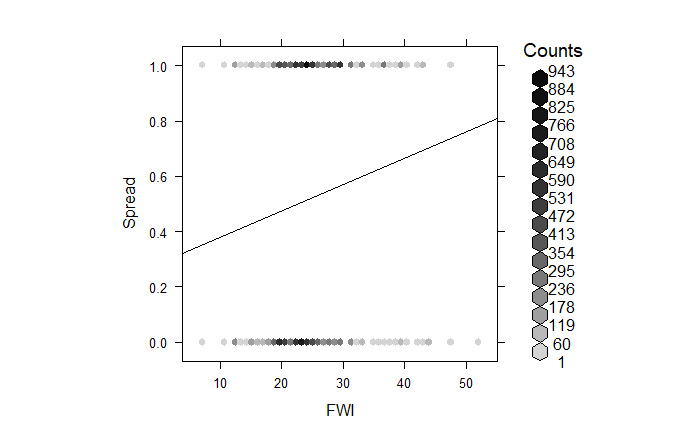

```r
#climate_day_complete<-climate_day_complete[,-1]

##Attaching a unique ID to each row in case we need it later
climate_day_complete <- cbind(1:nrow(climate_day_complete), climate_day_complete)

fix<-function(x){
return(as.numeric(as.character(x)))
}

##Renaming columns
#climate_day_complete<-climate_day_complete[,-1]
colnames(climate_day_complete) <- c("ID","FireName",  "date", "wind_region", "fuel_number", "uphill_azi", "slope",
                               "FWI","WSPD" , "spread","expansion")
climate_day_complete$expansion<-climate_day_complete$expansion*0.404686 ## To hectares
climate_day_complete$fuel_number<-climate_day_complete$fuel_number/3000
climate_day_complete$fuel_number[climate_day_complete$fuel_number >1.0]<-1.0



U_b <- 5 #mystery value of 'combustion bouyancy'. This changes based on fire severity. Check out GItHub and how its coded in SCRAPPLE itself

# relative.wd <-  wind.direction - upslope.azi
relative_wd <- as.numeric(climate_day_complete$WSPD) - as.numeric(climate_day_complete$uphill_azi)
climate_day_complete$effective_wsv <- U_b * ((fix(climate_day_complete$WSPD)/U_b) ^ 2 + 2*(fix(climate_day_complete$WSPD)/U_b) *
                sin(fix(climate_day_complete$slope)) * cos(relative_wd) + (sin(fix(climate_day_complete$slope))^2)^0.5)


hexbinplot(fix(climate_day_complete$spread)~fix(climate_day_complete$FWI),xlab="FWI",ylab="Spread",xbins=50,aspect=1,type="r")
```

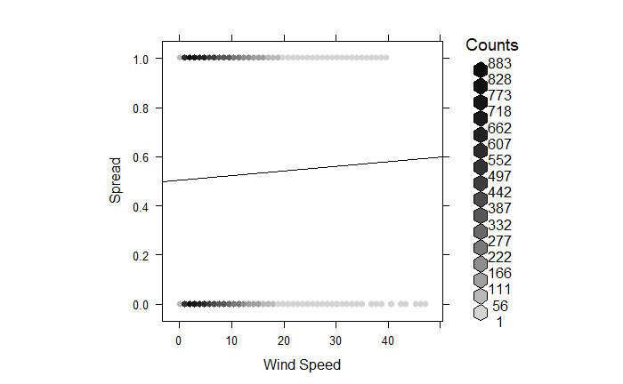

```r
hexbinplot(fix(climate_day_complete$spread)~fix(climate_day_complete$effective_wsv),xlab="Wind Speed",ylab="Spread",xbins=50,aspect=1,type="r")
```

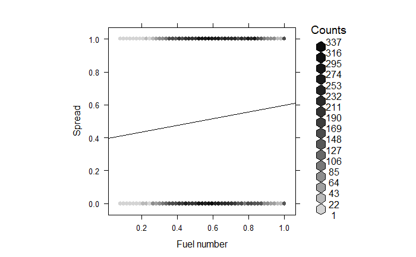

```r
hexbinplot(fix(climate_day_complete$spread)~fix(climate_day_complete$fuel_number),xlab="Fuel number",ylab="Spread",xbins=50,aspect=1,type="r")
```

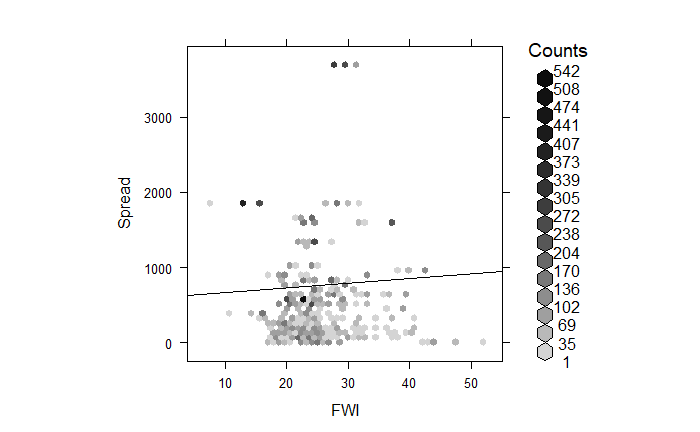

```r
hexbinplot(fix(climate_day_complete$expansion)~fix(climate_day_complete$FWI),xlab="FWI",ylab="Spread",xbins=50,aspect=1,type="r")
```

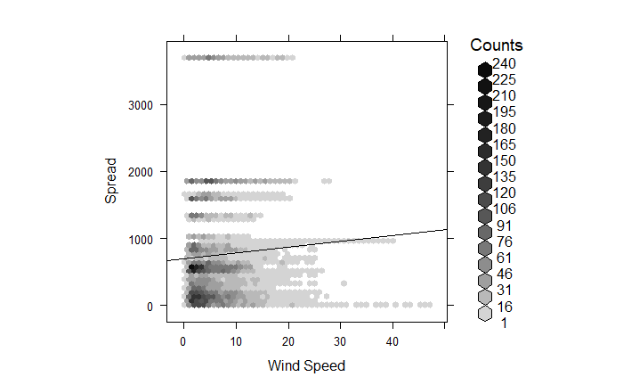

```r
hexbinplot(fix(climate_day_complete$expansion)~fix(climate_day_complete$effective_wsv),xlab="Wind Speed",ylab="Spread",xbins=50,aspect=1,type="r")
```

```r
spread_vars_short<-climate_day_complete
table(spread_vars_short$spread)
```

```
   0    1
6846 7368
```

```r
Full_logit <- glm(spread ~fix(FWI)+fix(effective_wsv),
                  data = spread_vars_short, family = "binomial")
summary(Full_logit)
```

```
Call:
glm(formula = spread ~ fix(FWI) + fix(effective_wsv), family = "binomial",
    data = spread_vars_short)

Deviance Residuals:
    Min       1Q   Median       3Q      Max
-1.7250  -1.1807   0.9297   1.1482   1.5604

Coefficients:
                    Estimate Std. Error z value Pr(>|z|)
(Intercept)        -0.902823   0.071437 -12.638  < 2e-16 ***
fix(FWI)            0.042321   0.003024  13.993  < 2e-16 ***
fix(effective_wsv) -0.009691   0.003346  -2.897  0.00377 **
---
Signif. codes:  0 ‘***’ 0.001 ‘**’ 0.01 ‘*’ 0.05 ‘.’ 0.1 ‘ ’ 1

(Dispersion parameter for binomial family taken to be 1)

    Null deviance: 19686  on 14213  degrees of freedom
Residual deviance: 19478  on 14211  degrees of freedom
AIC: 19484

Number of Fisher Scoring iterations: 4
```

```r
#hist(spread_vars_short$finefuels)
AIC(Full_logit)
```

```
[1] 19483.68
```

```r
FWI<-seq(0,max(spread_vars_short$FWI),.5)
xB<-exp((-0.892329)+ 0.039216*(FWI))
binomial2<-xB/(1+xB)

xB<-exp(( -0.892329  )+ 0.039216*(FWI))
binomial2min<-xB/(1+xB)

xB<-exp(( -0.892329  )+  0.039216*(FWI))
binomial2mean<-xB/(1+xB)

plot(FWI,binomial2,xlab="Fire Weather Index",ylab="Spread Probability",ylim=c(0,1),col="red")
points(FWI,binomial2mean)
```

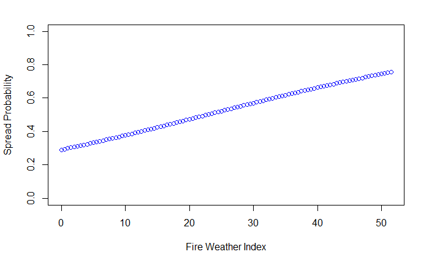

```r
points(FWI,binomial2min,col="blue")
```

[figure not shown]

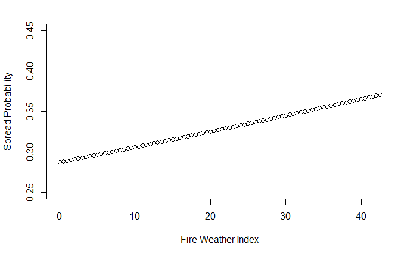

```r
WSS<-seq(0,max(spread_vars_short$FwI),.5)
xB<-exp((-0.909164)+0.008909*(WSS))
binomial<-xB/(1+xB)
plot(WSS,binomial,xlab="Fire Weather Index",ylab="Spread Probability",ylim=c(.25,.45))
points(WSS,binomial2,col="red")
```

### Max spread.

[figure not shown]

```r
colnames(check)<-c("expansion","FWI")
```

```r
#?glm()
summary(Expansionfull)
```

```
Call:
lm(formula = fix(expansion) ~ FWI, data = check)

Residuals:
   Min     1Q Median     3Q    Max
-480.4 -301.7 -146.2  146.6 3248.5

Coefficients:
            Estimate Std. Error t value Pr(>|t|)
(Intercept)  282.877    206.852   1.368    0.174
FWI            5.059      8.086   0.626    0.533

Residual standard error: 496.6 on 119 degrees of freedom
Multiple R-squared:  0.003278,  Adjusted R-squared:  -0.005098
F-statistic: 0.3914 on 1 and 119 DF,  p-value: 0.5328
```

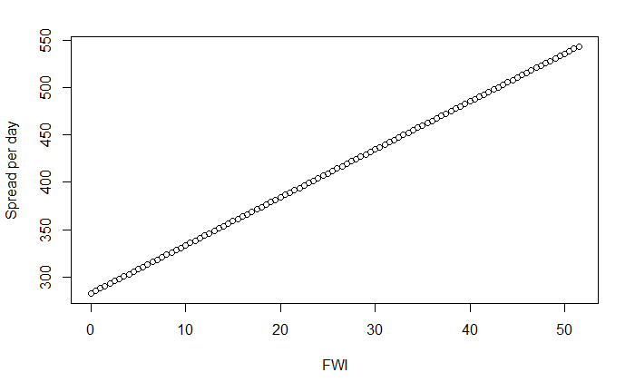

```r
FwI<-seq(0,max(spread_vars_short$FWI),.5)
FWI_Spread<- 282.877+(5.059*FwI)
plot(FwI,FWI_Spread,xlab="FWI",ylab="Spread per day")
```